# Chapter VI: Synthesis and discussion

How do ordinary people conceptualize mental life, and how do these conceptual representations emerge and change across development? The goal of this dissertation was to explore the development of conceptual representations of mental life over early and middle childhood in the modern US context. In the preceding chapters, I argued that a simple empirical approach—asking children straightforward questions about whether familiar entities possessed specific mental capacities (e.g., “Can a beetle feel happy?”)—can offer deep insights into the cognitive architecture that supports children’s understanding of mental life. In particular, I provided an in-depth analysis of three aspects of conceptual development in this domain: (1) the conceptual units that anchor representations of mental life; (2) the organization of these conceptual units with respect to one another; and (3) the deployment of these representations in reasoning about animate beings vs. inanimate objects. Together, these analyses sketch a picture of a developmental “endpoint” for these representations among US adults and provide the first glimpse of a developmental trajectory between 4-9y of age as US children learn to reason like the adults in their cultural context.

Here I step back to synthesize what these studies have revealed about conceptual development in this domain, and to speculate about the implications of these findings for social development.

# An emerging theory of conceptual units, their organization, and their deployment

US adults’ representations of mental life are anchored by three conceptual units: BODY, HEART, and MIND. Early in life, children have access to a more limited set of conceptual units; by the preschool years, they make a broad distinction between the more visceral sensations of the BODY and the more cognitive abilities of the MIND, but have no notion of social-emotional abilities as a third, unified class of mental states. Over the course of early childhood, the set of conceptual units available to children expands in number as HEART emerges as a distinct construct; each of these conceptual units also undergoes further refinements in its content and size. The set of conceptual units reaches an adult-like state some time in the early elementary school years (i.e., early enough to appear “mature” in a snapshot of 7- to 9-year-old children).

Even by the preschool years, however—well before these conceptual units are fully mature—children already consider physiological sensations (BODY) to be particularly basic or fundamental aspects of mental life, and they quickly come to see perceptual-cognitive abilities (MIND) as roughly equally “basic.” The social-emotional abilities of the HEART are already perceived to be less basic, i.e., to occupy a different position in the hierarchical structure that characterizes this conceptual domain (even though they are not yet perceived as constituting a unified third construct distinct from BODY and MIND). Over the course of early and middle childhood (and likely into adolescence), these hierarchical relationships become increasingly stark, applying more universally to any kind of “being” in the world, and the degree of consensus across individuals increases. In its “mature” state, this hierarchical structure admits of virtually no exceptions: It governs mental capacity attributions to all kinds of target entities among all individual people.

The final element of this relational structure to emerge—perhaps at some point in adolescence—is that HEART comes to be seen as not only dependent on both BODY and MIND, but *jointly* dependent on their combination. This understanding of joint dependency may emerge from one or more intuitive theories, such as a theory of how emotions work (e.g., that affective experiences have both physiological and cognitive components), or an understanding of emotions as fundamentally social phenomena (e.g., that the only entities capable of emotional experiences are social beings, and the only entities capable of social relationships are living beings with a certain degree of “intelligence”).

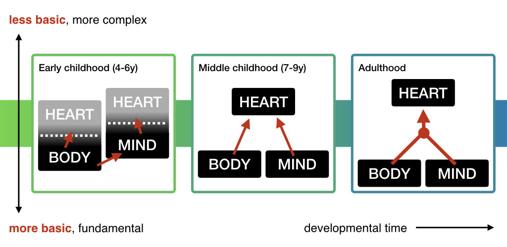

Figure 6.1: A visual depiction of my working theory of conceptual development in representations of mental life in the modern US context, featuring snapshots of this conceptual structure at three points in development. Conceptual units are depicted as black boxes. Hierarchical relationships are depicted as red arrows, with the arrowhead pointing to the less “basic” unit. The red node that these arrows pass through in the “Adulthood” snapshot represents the perceived *joint* dependency of HEART on both of the more basic units (BODY and MIND).

Related to this question of which entities in the world possess or participate in which aspects of mental life, from early in childhood, children’s distinction between animate beings vs. inanimate objects includes an understanding—shared with adults in their cultural context—that animate beings are generally more likely to have any kind of mental capacities than inanimate objects. The BODY, in particular, is the primary axis of this distinction throughout childhood and in adulthood, with this distinction increasing in size and reliability over early and middle childhood (and perhaps beyond).

At some point in later childhood or perhaps adolescence, children come to believe that only animates, but not all animates, have social-emotional abilities—i.e., that biological animacy is necessary, but not sufficient, for HEART. Likewise, children eventually come to believe that most animates, but also some inanimates, have perceptual-cognitive abilities—i.e., that biological animacy is broadly sufficient, but not necessary, for MIND. These adjustments to the conceptual connections between mental life and animacy result in general decreases in attributions of HEART, and increases in attributions of MIND.

Finally, at some point in later childhood or adolescence, children come to share adults’ intuitions (which might be considered “over-hypotheses”; Goodman, 1955) that animate beings are distinct from inanimate objects not only in that their mental capacities are, on average, superior (especially in the BODY domain)—but also in that their mental capacities are more variable across specific entities, and more correlated across domains (BODY, HEART, and MIND).

Testing and refining this emerging theory will require extensive follow-up studies with children in the current age range (4-9y) as well as older children and adolescents. Particularly useful would be studies that employ truly *experimental* designs testing specific hypotheses. To give just a few examples:

1. To test the hypothesis that preschool-age children consider physiological sensations to be more similar to social-emotional abilities than do older children (as indicated by the EFA solutions reported in Chapter III), one might ask children to make inductive inferences from one mental capacity to another (e.g., to make guesses about the mental capacities of an unfamiliar entity that is known to have a capacity for, say, hunger), with the prediction that inferences from physiological sensations to social-emotional abilities (and vice versa) will decline in strength between 4-9y of age.
2. To test the hypothesis that adults consider the physiological sensations of the BODY and the perceptual-cognitive abilities of the MIND to be more “basic” or “fundamental” than the social-emotional abilities of the HEART (as indicated by the analyses of asymmetries in mental capacity attributions reported in Chapter IV), one could provide adult participants with some operational definition of “basic” and ask adults to rate the “basic-ness” of a wide range of mental capacities, with the prediction that the mental capacities associated with HEART in the current studies would be rated as less “basic” than the capacities associated with BODY or MIND.
3. To test the hypothesis that, sometime between middle childhood and adulthood, children come to think of biological animacy as necessary but not sufficient for the social-emotional abilities of the HEART (as suggested by the differences between children and adults in their attributions of HEART to animates vs. inanimates reported in Chapter V), one might ask children and adolescents (covering a wide age range, e.g., 7-17y) explicit questions about the relationship between animacy and social-emotional experience. For example, one could ask broad questions about the general relationship between animacy and HEART (e.g., “Is there anything that’s not alive but still as emotions?”), or more pointed questions about specific beings that might plausibly be considered to have HEART without being a living thing (e.g., “What about a really advanced kind of robot, do you think it could ever have any kind of emotions?”; “What about something like a spirit or a ghost—do you think that could be real, and if it were real, do you think it could ever have any kind of emotions?”). If the differences documented in Chapter V are truly *developmental* differences, one would predict that answers to these questions would become more negative with age over the course of later childhood and adolescence; if any of these differences were reflective of cohort differences, rather than development, one would predict that even adolescents might answer these questions more positively than adults.

These are just a few of the ways in which specific aspects of this theory could be probed in more focused confirmatory tests. In addition to this, examining snapshots of a larger number of narrower age ranges between early childhood and adulthood; developing analyses that aim to capture these aspects of conceptual development more continuously, rather than binning children into age groups; and designing longitudinal studies to capture conceptual change at the level of the individual, rather than in the aggregate, could all provide converging evidence or could challenge the theoretical framework I have proposed.

# “Edge cases” vs. “diverse characters” approaches

Across the current studies, I employed two strategies for gauging conceptual representations of mental life through variability in participants’ mental capacity attributions: (1) asking participants to assess the mental capacities of two selected “edge cases” in social reasoning, whose mental lives I presumed would elicit different responses across individual participants (a beetle and a robot; Studies 1a-1c, 2, and 4); and (2) asking participants to assess a diverse range of target characters (e.g., humans and a wide variety of other animals, technologies, inert objects), whose mental lives I presumed would be perceived to differ (Study 1d and Study 3). These two “variants” of my experimental approach were introduced in Chapter II; here I discuss the extent to which they provided converging or diverging evidence about conceptual units, their organization, and the deployment of representations of mental life over development.

The two studies with younger children (Study 3, “diverse characters” variant; Study 4, “edge case” variant) varied along so many dimensions—the set of mental capacities included; the physical setup, experimental setting, experimenter’s script, and the amount of scaffolding provided for using the response scale; the between- vs. within-subjects design; the average age of participants—that differences between studies cannot reasonably be interpreted as arising from differences in the variant of the experimental approach alone. Given this, I focus my comparisons of these two variants on adults (seven samples: Studies 1a-1d, 2, 3, and 4) and 7- to 9-year-old children (two samples: Study 2 and Study 3).

### Conceptual units

In terms of conceptual units (Chapter III), the “edge case” and “diverse characters” variants appear to have yielded very similar results.

Among adults, all seven datasets were well accounted for by a three-factor exploratory factor analysis solution featuring conceptual units corresponding to BODY, HEART, and MIND. There was only one adult sample—in Study 2, one of the five studies with adults to employ the “edge case” variant of the approach—for which there was any compelling evidence for a more complex solution (featuring four or more factors), and no adult samples for which there was any indication of a simpler underlying structure (featuring fewer than three factors; see Chapter III, Table 3.1). The BODY, HEART, and MIND factors were qualitatively very similar across adult samples, and accounted for similar proportions of the shared variance in each EFA solution (see Chapter III, Figure 3.5, panel C).

### Organization

In terms of the organization of these conceptual units (Chapter IV), the “edge case” and “diverse characters” approaches both appear to have captured the more stable aspects of the relationships between BODY, HEART, and MIND (namely, that BODY and MIND appear to be more “basic” than HEART), while each also revealing somewhat different aspects of the finer details of this relational structure (including the nature of the relationship between BODY and MIND, as well as the strength of the correlations among all three conceptual units).

Among adults, the asymmetries in scores on the *BODY* vs. *HEART* scales were strikingly consistent across studies: Virtually all adult participants, in all studies, endorsed BODY abilities at least as strongly as, and often more strongly than, HEART abilities—regardless of which character they assessed (and, by extension, regardless of which variant of the experimental paradigm was employed in that study). The same could be said of the asymmetries in scores on the *MIND* vs. *HEART* scales: Virtually all adult participants, in all studies, endorsed MIND abilities at least as strongly as, and often more strongly than, HEART abilities. The MIND vs. HEART asymmetry appears to have been estimated to be slightly smaller in the two adult samples from studies that used the “diverse characters” variant (Study 1d and Study 3) than in the samples from studies that used the “edge cases” variant (Studies 1a-1c, 2, and 4), but the asymmetry was clearly present in all adult samples. In Chapter IV I took these reliable asymmetries to be evidence that BODY and MIND are more basic, fundamental aspects of mental life, while HEART is more complex and contingent on the presence of BODY and MIND. The “edge case” and “diverse characters” variants of the experimental approach both provided strong evidence for this aspect of the relational structures among conceptual units among adults.

Among 7- to 9-year-old children it also seems to be true that both variants of the experimental approach yielded similar pictures of the relationships between BODY vs. HEART and MIND vs. HEART: The asymmetries between the more “basic” units (BODY and MIND) vs. HEART were generally similar across the two samples of older children, regardless of which variant of the experimental approach was employed. The only exception to this was that in Study 2 (“edge case” variant), the asymmetry in 7- to 9-year-old children’s *BODY* vs. *HEART* scores appears to have been smaller than the corresponding asymmetry in Study 3 (“diverse characters” variant); after accounting for other aspects of the experimental design this asymmetry was not differentiable from zero.

Meanwhile, the “edge case” and “diverse characters” variants of the experimental approach yielded much more variable pictures of the relationship between the two more “basic” units—BODY and MIND, both among adults and among 7- to 9-year-old children.

Among adults, all five of the studies that featured edge cases as target characters suggested that adults tended to endorse MIND more strongly than BODY (albeit not with the same strictness as in the BODY vs. HEART and MIND vs. HEART asymmetries just described); indeed, these studies estimated this asymmetry to be roughly as strong as the asymmetry between BODY vs. HEART. The two studies that featured diverse characters, however, appear to have estimated this asymmetry in adults’ *BODY* vs. *MIND* scores to be much smaller and more variable across target characters, with some target characters eliciting asymmetries in the opposite direction (stronger endorsements of BODY than MIND).

This same pattern holds true among 7- to 9-year-old children: In Study 2 (“edge case” variant), children tended to endorse MIND more strongly than BODY on average, while in Study 3 (“diverse characters” variant), there was no systematic asymmetry in children’s *BODY* vs. *MIND* scores, which reflected the fact that this asymmetry ran in opposite directions for different target characters.

A final aspect of the relationships among conceptual units that I explored in Chapter IV was the correlations among scores on *BODY*, *HEART*, and *MIND* scales. In general, scores on all three scales were positively correlated, as I would expect if all three scales tapped into different aspects of the same more general phenomenon (what I have called “mental life”). However, among both adults and 7- to 9-year-old children, the correlations between BODY vs. MIND appear to have been much stronger in studies that employed the “diverse characters” variant of the approach (Study 1d and Study 3) than in studies that employed the “edge cases” variant (Studies 1a-1c, 2, and 4). A post-hoc visual inspection of Figure 4.1, panel D2, and Figure 4.6, panel A2, suggests that this may be due to the inclusion of more animate than inanimate characters: In both cases, the correlations between BODY vs. MIND appears to have been quite strong among animate characters, and closer to zero among inanimate characters, and the preponderance of animate characters in these studies (17 animates vs. 4 inanimates in Study 1d; 5 animates vs. 4 inanimates in Study 3) may have tipped the balance toward stronger correlations in these cases. Whether these are inflated estimates of the BODY-MIND relationship (because of this imbalance in experimental design), or more accurate estimates (because this imbalance favors the kinds of entities that are the primary targets of reasoning about mental life in the course of most people’s ordinary lives) is a difficult judgment to make.

In sum, for both adults and 7- to 9-year-old children, the relationships among BODY and MIND, on the one hand, and HEART, on the other, were generally similar across the two variants of the experimental approach, both in the strength of the positive correlations across conceptual units (if a target was judged to have BODY or MIND abilities, it was more likely to be judged to have HEART abilities) and in the asymmetries between more “basic” vs. less “basic” units (targets were generally judged to have more BODY and MIND abilities than HEART abilities). In contrast, correlations and asymmetries between these two more basic conceptual units, BODY and MIND, appear to have been varied more in their manifestations across the “edge case” vs. “diverse characters” approaches—seemingly because the nature of these relationships seems to have varied across target characters and animacy status. This would not have been clear if I had only conducted studies that employed the “edge case” variant of the experimental approach.

### Deployment

In terms of the deployment of these conceptual representations (Chapter V), the “edge case” and “diverse characters” approaches again both appear to have captured the most stable and striking aspects of participants’ use of BODY, HEART, and MIND in their reasoning about various entities in the world, while also revealing somewhat different aspects of the finer details of this application of the concept in question.

Among adults, both variants of the experimental approach highlighted the BODY domain as the primary site of distinction between animate vs. inanimate target charters. Both variants also revealed a distinction between animates vs. inanimates in adults’ attributions of HEART (like BODY, adults tended to attribute more HEART to animates than to inanimates), but these differences were largest in the studies that employed the “diverse characters” variant (Study 1d and Study 3). Likewise, adults’ distinction between animates vs. inanimates in the MIND domain was much greater using the “diverse characters” variant—and, if anything, seemed to run in the opposite direction when using the “edge cases” variant (with adults tending to attribute slightly more MIND to inanimate robots than to animate beetles in Studies 1a-1c, 2, and 4). All of these observations also held true for 7- to 9-year-old children in Study 2 (“edge case” variant) vs. Study 3 (“diverse characters” variant); see Figure 5.7.

In terms of general age-related differences in attributions beyond the animate-inanimate distinction, the seemingly largest and most robust of these general age-related trends—over-attributions of HEART—was clear across Studies 2-4, regardless of which variant was employed; the “edge case” variant (employed in Study 2 and Study 4) appears to have drawn particular attention to this tendency, but it was also apparent among the “diverse characters” featured in Study 3. The weaker age-related trends—possible tendencies to over-attribute BODY and to under-attribute MIND, relative to adults—were more contingent on which target characters were included in the study; see Figure 5.7.

In my view, this particular aspect of conceptual representations of mental life—what I have called their “deployment” or application to specific real-world cases—is best captured by the “diverse characters” variant of the experimental approach. I believe including a wider range of target characters provides a more comprehensive and ecologically valid picture of the deployment of this conceptual structure, because it includes more of the range of entities that are the primary targets of reasoning about mental life in the course of most people’s ordinary lives. If anything I would suggest that future studies with children aim to include an even more “diverse” and representative set of characters, such as inert objects that are not anthropomorphic, natural non-living things, plants (see, e.g., Inagaki, 1996; Ojalehto, Medin, & García, 2017), and a wider range of animates, including a variety of humans.

# Three *interconnected* aspects of conceptual development?

Throughout this dissertation, I have considered the development of conceptual units, their organization, and their deployment independently, one by one—but of course, these three passes at analysis and interpretation made use of the same datasets, and the theory that is emerging from this work suggests that several different conceptual changes are unfolding simultaneously or in overlapping time courses. How might these aspects of development in this domain relate to or inform each other?

Again, my comments on this topic are highly speculative, and I share them here with the purpose of laying the groundwork for future tests, refinements, and revisions.

First, I would like to highlight the possibility of a dynamic interplay between the development of conceptual units (Chapter III) and their organization (Chapter IV). In the current studies, there were examples of children demonstrating adult-like sensitivities to hierarchical relationships among mental capacities *before* demonstrating adult-like distinctions among conceptual units: For example, in the aggregate even 4- to 6-year-old children appeared to treat the physiological sensations of the BODY as more “basic” than the social-emotional abilities of the HEART (Chapter IV, Study 3 and Study 4), although as a group these children did not clearly distinguish between BODY and HEART (Chapter III, Study 3 and Study 4). At the same time, there were also examples of children’s sense of hierarchical relationships being refined well after they appeared to have mastered the distinctions among conceptual units: For example, in the aggregate 7- to 9-year-old children’s distinctions between BODY, HEART, and MIND appeared to be very robust and adult-like (Chapter III, Study 2 and Study 3), but the asymmetries in their attributions of BODY and MIND, on the one hand, and HEART, on the other, were not nearly as pronounced or as strict as the corresponding asymmetries among adults (among whom there were virtually no exceptions to the rule that *BODY* and *MIND* scores should always be at least as high, if not higher, than *HEART* scores; Chapter IV, Studies 1-3). In other words, an emerging sense of hierarchical relationships seems to be a precursor of more robust and adult-like distinctions among conceptual units in early childhood—but these hierarchical relationships continue to be refined (in this case, strengthened) well after the point at which children appear to have mastered these distinctions among conceptual units. Taken together, this suggests that these two aspects of conceptual development might mutually inform each other in a sort of feedback cycle over early and middle childhood.

Meanwhile, I have come to see the age-related differences in the *deployment* of these conceptual representations—in particular, children’s over-attribution of HEART, relative to adults, which appears to extend well into middle childhood—as possible relics of earlier shifts in conceptual units and their organization. Even the oldest children in these studies attributed markedly more in the way of HEART, to both animate and inanimate beings, than did adults—even though these same children appeared to share adults’ sense of BODY, HEART, and MIND, the general organizational structure of these three conceptual units, and even the ways in which animates vs. inanimates might vary in these three domains. Could it be the case that these over-attributions of HEART are rooted in the fact that these social-emotional abilities were only distinguished as a third aspect of mental life relatively recently? Could the “liberation” of HEART from BODY and MIND result in a period of over-zealousness about which beings in the world might have capacities in this domain, with social-emotional abilities attributed even to beings with limited BODY abilities (like robots), or limited MIND abilities (like beetles)? How might this kind of account apply to children’s earlier over-attributions of BODY, or to the more subtle under-attributions of MIND?

In my view, rigorous explorations these possibilities would require adopting experimental methods and analyses that are capable of diagnosing conceptual units, their organization, and their deployment at the level of an individual child—the current studies and analyses are not sufficient. But they have opened the door to these kinds of questions, which I hope to explore in future work.

# Implications for social development: BODY, HEART, and MIND as “lenses” through which to view a being

In discussing BODY, HEART, and MIND as “conceptual units” that anchor representations of mental life, I have drawn on the language and mindset of ontology, presenting these three aspects of mental life as component parts of a larger concept, or as categories of mental capacities.

Here, I would like to propose another way of thinking about BODY, HEART, and MIND: as distinct *modes of social reasoning*. I will draw on the metaphor of BODY, HEART, and MIND as offering different “lenses” through which an observer might “view” another being’s behavior—each lens being associated with a different set of knowledge, concepts, and theories about one aspect of a being’s existence and identity, thereby making available to the observer specific ways of interacting with that being.[^1]

Consider first: BODY. In the current studies with adults and 7- to 9-year-old children, this conceptual unit was identified by a strongly correlated suite of physiological sensations corresponding to biological needs (e.g., hunger, pain, fatigue), but also included basic affective responses related to physical survival (e.g., fear, pleasure) as well as mental capacities that support the self-initiated behaviors required to meet those needs (e.g., desire, free will; see Chapter III, as well as Weisman et al., 2017). Taken together, this suite of mental capacities calls to mind previous work on “folk biology,” a conceptual system hypothesized to support an observer’s reasoning about living creatures who are subject to biological needs and are motivated to action to satisfy these needs (e.g., Carey, 1985; Wellman & Gelman, 1992). Viewing another being as a living creature might focus an observer’s attention on the more embodied aspects of that being’s mental life, and might lead this observer to interact with the being in ways typically reserved for animals.

But the “living creature” lens is just one way to think about another being. Consider next the conceptual unit that I have called HEART. In the current studies, this unit was exemplified by both basic emotional experiences (e.g., happiness, sadness) and many more complex social emotions (e.g., pride, guilt), as well as mental capacities that support moral agency (e.g., an understanding of right and wrong, self-restraint). This calls to mind work on the conceptual underpinnings of social cognition, including reasoning about the interactions, affiliations, and moral status of social partners (e.g., Hamlin, 2013; Hamlin et al., 2013; Spelke, Bernier, & Skerry, 2013; Spelke & Kinzler, 2007). Viewing another being as a social partner might focus an observer’s attention on the more affective or emotional aspects of that being’s mental life, and might lead this observer to interact with the being in ways typically reserved for friends, family members, and other social partners.

Finally, consider the third conceptual unit that emerged from the current studies: MIND. In the current studies, this unit was identified by a functionally related suite of mental capacities that encompasses perceptual experiences (e.g., vision, hearing), cognitive abilities (e.g., memory), and goal pursuit (e.g., planning, making choices). This calls to mind the extensive literature on the more representational aspects of “theory of mind” (e.g., Wellman & Gelman, 1992; Wellman & Woolley, 1990)—the domain of reasoning that deals with planful, intentional agents who take in, store, and make use of information about their surroundings in order to achieve certain goals or end-states. Viewing another being as a goal-directed agent might focus an observer’s attention on that being’s perceptions, thoughts, beliefs, and plans, and might lead this observer to interact with the being in ways typically reserved for intelligent beings.

On this account, in any given interaction an observer might draw on one or more of these lenses to form interpretations, explanations, and predictions about another being’s behaviors. Indeed, another gloss on this proposal would be that BODY, HEART, and MIND pick out three parallel lay theories of motivated action, akin to the “BELIEF + DESIRE = ACTION” framework that is so fundamental to many psychological theories, both in cognitive psychology and cognitive development (e.g., Schank & Abelson, 1975; Wellman & Woolley, 1990), and also in social psychology and affective science (Dweck, 2017; Gross, 2015).

In addition to suggesting three distinct “lenses”—or three parallel “theories”—that may play particularly important roles in the reasoning of US adults, the current work also suggests that some of these lenses or theories might be more fundamental (and perhaps more widely shared across ages and cultural contexts), while others—namely, the “social partner” lens/theory corresponding to the conceptual unit HEART—may be acquired, distinguished, or refined over an extended period of experience with the world, likely involving socialization and extensive social-cultural input. For the US children in the current studies, the finding that the social-emotional abilities may only gradually be distinguished from physiological sensations (BODY) and perceptual-cognitive abilities (MIND) over the course of early childhood suggests, for example, that preschool-age children may not have access to a distinct lens/theory for making sense of others as social partners, and instead rely on more fundamental theories of agents (MIND) and animals (BODY) to navigate the social world (each of which might incorporate more about social-emotional abilities than the corresponding MIND and BODY lenses/theories of US adults).

I highlight these speculations and connections to previous work not only because I find them interesting in their own right, but also because I see them as a bridge between the current project—which has been focused mainly on describing a *lay ontology* of mental life—and the ongoing fascination in cognitive science and developmental psychology with the *lay theories* that guide people’s inferences, predictions, explanations, and behaviors. In my view it would be deeply rewarding to bring the current ontological project “to life” by connecting it to this rich tradition of work on lay theories—and, likewise, to ground ongoing work on “lay psychology” and “theory of mind” in the ecologically valid picture of children’s developing ontologies of mental life that has emerged from the studies in this dissertation.

# References

Carey, S. (1985). *Conceptual Change in Childhood*. Cambridge, MA: MIT Press.

Dweck, C. S. (2017). From Needs to Goals and Representations: Foundations for a Unified Theory of Motivation, Personality, and Development. *Psychological Review*, *124*(6), 689–719. https://doi.org/10.1037/rev0000082

Goodman, N. (1955). *Fact, Fiction, & Forecast*. Retrieved from http://ezp-prod1.hul.harvard.edu/login?url=http://search.ebscohost.com/login.aspx?direct=true{\&}db=psyh{\&}AN=1955-04889-000{\&}site=ehost-live{\&}scope=site

Gross, J. J. (2015). Emotion Regulation: Current Status and Future Prospects. *Psychological Inquiry*, *26*(1), 1–26. https://doi.org/10.1080/1047840X.2014.940781

Hamlin, J. K. (2013). Moral Judgment and Action in Preverbal Infants and Toddlers: Evidence for an Innate Moral Core. *Current Directions in Psychological Science*, *22*(3), 186–193. https://doi.org/10.1177/0963721412470687

Hamlin, J. K., Ullman, T., Tenenbaum, J., Goodman, N., & Baker, C. (2013). The mentalistic basis of core social cognition: Experiments in preverbal infants and a computational model. *Developmental Science*, *16*(2), 209–226. https://doi.org/10.1111/desc.12017

Inagaki, K. (1996). Young children’s recognition of commonalities between animals and plants. *Child Development*, *67*(6), 2823–2840.

Ojalehto, bethany l., Medin, D. L., & García, S. G. (2017). Conceptualizing agency: Folkpsychological and folkcommunicative perspectives on plants. *Cognition*, *162*, 103–123. https://doi.org/10.1016/j.cognition.2017.01.023

Schank, R. C., & Abelson, R. P. (1975). Scripts, Plans, and Knowledge. *Proceedings of the 4th International Joint Conference on Artificial Intelligence*, 151–157.

Spelke, E. S., Bernier, E. P., & Skerry, A. E. (2013). Core social cognition. In M. R. Banaji & S. A. Gelman (Eds.), *Navigating the social world: What infants, children, and other species can teach us* (pp. 11–16). Retrieved from http://www.wjh.harvard.edu/{~}lds/pdfs/Spelke{\_}Bernier{\_}Skerry{\_}2013chapter.pdf

Spelke, E. S., & Kinzler, K. D. (2007). Core knowledge. *Developmental Science*, *10*(1), 89–96. https://doi.org/10.1111/j.1467-7687.2007.00569.x

Weisman, K., Dweck, C. S., & Markman, E. M. (2017). Rethinking people’s conceptions of mental life. *Proceedings of the National Academy of Sciences*, *114*(43), 11374–11379. https://doi.org/10.1073/pnas.1704347114

Wellman, H. M., & Gelman, S. A. (1992). Cognitive development: Foundational theories of core domains. *Annual Review of Psychology*, *43*, 337–375.

Wellman, H. M., & Woolley, J. D. (1990). From simple desires to ordinary beliefs: The early development of everyday psychology. *Cognition*, *35*(3), 245–275. https://doi.org/10.1016/0010-0277(90)90024-E

[^1]: This paragraph and the following three paragraphs are adapted from a manuscript currently in revision. See also Weisman et al. (2017) for an earlier take on the resonance between BODY, HEART, and MIND, on the one hand, and lay biology, social partnership, and representational theory of mind, on the other.